# CLT Convergence: Binomial Small

```r
source("../R/clt_functions.R")

student_id <- 8515     # last 4 digits of my student ID
B          <- 10000    # number of simulated samples (NOT the sample size)
pop        <- "binom_small"
```

## 1. What does the population look like?

X ~ Binomial(size = 5, p = 0.10), generated with `rbinom()`. Takes only the values 0-5, and about 59% of draws are 0.

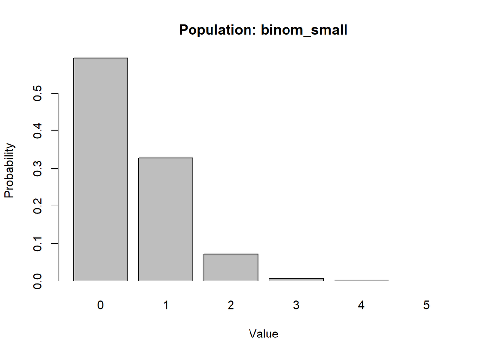

```r
plot_population(pop, seed = student_id)
```

The population is discrete and can only take the values 0 to 5. It is strongly right-skewed (skewness ≈ 1.19): about 59% of draws are 0, 33% are 1, 7% are 2, and values of 3 or more happen less than 1% of the time. The bar chart is a tall bar at 0 that drops off quickly. It satisfies every CLT assumption (independent, identically distributed, finite variance), so the CLT applies, but both the skew and the discreteness should slow convergence.

## 2. Theoretical mean and standard deviation

Theoretical mean = 5(0.1) = 0.5, SD = √(5·0.1·0.9) ≈ 0.671, so SE(X̄) = 0.671/√n.

## 3. Prediction (write this BEFORE running the simulations)

Prediction: This population is very skewed to the right and highly discrete: most draws are 0, and values of 3 or more are rare. I expect the sample mean to stay skewed and choppy for a while, and predict it will need more than 30, perhaps around n = 50, before it looks normal. I expect the simulated mean to be near 0.5 and the SE to match 0.671/√n.

## 4. Which sample sizes did I investigate?

**Pass 1 (coarse):** a wide grid to find roughly where the change happens.

```r
ns_coarse <- c(2, 5, 10, 20, 30, 50, 100, 200, 500)
coarse    <- run_study(pop, ns_coarse, B = B, seed = student_id)
knitr::kable(coarse$table, digits = 4)
```

| n | sim_mean | theo_mean | sim_se | theo_se | se_ratio | skewness | ex_kurt | qq_cor | shapiro_p |
| --- | --- | --- | --- | --- | --- | --- | --- | --- | --- |
| 2 | 0.5030 | 0.5 | 0.4774 | 0.4743 | 1.0064 | 0.8660 | 0.5557 | 0.9171 | 0.0000 |
| 5 | 0.4950 | 0.5 | 0.3000 | 0.3000 | 1.0001 | 0.5608 | 0.2830 | 0.9695 | 0.0000 |
| 10 | 0.4957 | 0.5 | 0.2119 | 0.2121 | 0.9987 | 0.3851 | 0.1521 | 0.9860 | 0.0000 |
| 20 | 0.4978 | 0.5 | 0.1518 | 0.1500 | 1.0122 | 0.2731 | 0.0283 | 0.9931 | 0.0000 |
| 30 | 0.4990 | 0.5 | 0.1232 | 0.1225 | 1.0055 | 0.2346 | 0.0945 | 0.9953 | 0.0000 |
| 50 | 0.4991 | 0.5 | 0.0940 | 0.0949 | 0.9910 | 0.1726 | 0.1041 | 0.9972 | 0.0000 |
| 100 | 0.4992 | 0.5 | 0.0668 | 0.0671 | 0.9954 | 0.1028 | 0.0217 | 0.9987 | 0.0000 |
| 200 | 0.4997 | 0.5 | 0.0475 | 0.0474 | 1.0012 | 0.0672 | 0.0365 | 0.9994 | 0.0005 |
| 500 | 0.4994 | 0.5 | 0.0301 | 0.0300 | 1.0044 | 0.0669 | 0.0796 | 0.9996 | 0.0275 |

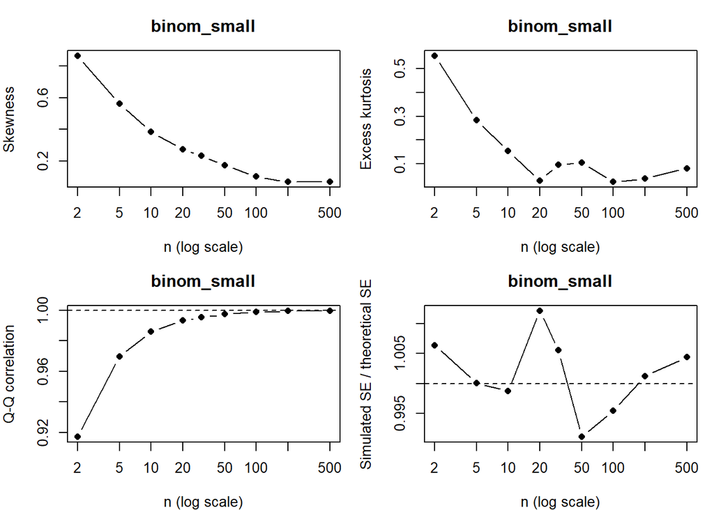

```r
plot_convergence(coarse$table, pop)
```

**Pass 2 (refined):** narrower values around the transition.

```r
ns_fine <- c(25, 30, 35, 40, 45, 50, 60, 70, 80)   # pass 1 changed between n = 50 and n = 100
fine    <- run_study(pop, ns_fine, B = B, seed = student_id)
knitr::kable(fine$table, digits = 4)
```

| n | sim_mean | theo_mean | sim_se | theo_se | se_ratio | skewness | ex_kurt | qq_cor | shapiro_p |
| --- | --- | --- | --- | --- | --- | --- | --- | --- | --- |
| 25 | 0.4983 | 0.5 | 0.1344 | 0.1342 | 1.0018 | 0.2125 | 0.0053 | 0.9949 | 0 |
| 30 | 0.4990 | 0.5 | 0.1232 | 0.1225 | 1.0055 | 0.2346 | 0.0945 | 0.9953 | 0 |
| 35 | 0.4990 | 0.5 | 0.1135 | 0.1134 | 1.0013 | 0.2149 | 0.0675 | 0.9959 | 0 |
| 40 | 0.4990 | 0.5 | 0.1062 | 0.1061 | 1.0009 | 0.1998 | 0.1103 | 0.9965 | 0 |
| 45 | 0.4990 | 0.5 | 0.0997 | 0.1000 | 0.9966 | 0.1881 | 0.1078 | 0.9969 | 0 |
| 50 | 0.4991 | 0.5 | 0.0940 | 0.0949 | 0.9910 | 0.1726 | 0.1041 | 0.9972 | 0 |
| 60 | 0.4998 | 0.5 | 0.0873 | 0.0866 | 1.0080 | 0.1698 | 0.1919 | 0.9976 | 0 |
| 70 | 0.4996 | 0.5 | 0.0805 | 0.0802 | 1.0038 | 0.1451 | 0.1130 | 0.9980 | 0 |
| 80 | 0.4995 | 0.5 | 0.0747 | 0.0750 | 0.9962 | 0.1578 | 0.0191 | 0.9980 | 0 |

In pass 1, n = 50 failed my standard and n = 100 passed, and skewness was already close to the cutoff around n = 20–30. I refined from 25 to 80 in steps of 5 and 10 to find where all three criteria pass and keep passing.

## 5. Simulated vs. theoretical mean and standard error

The table columns `sim_mean` / `theo_mean` and `sim_se` / `theo_se` compare the simulation with the CLT’s predictions. `se_ratio` = simulated SE ÷ σ/√n, so 1 means a perfect match.

## 6. My “normal enough” standard and the chosen n

```r
# My "normal enough" standard, used identically in every file
criteria <- list(
  max_abs_skew = 0.25,    # mild skew; tighter is within Monte Carlo noise
  max_abs_kurt = 0.3,     # tails close to normal
  min_qq_cor   = 0.998    # Q-Q plot essentially straight
)

all_results <- rbind(coarse$table, fine$table)
all_results <- all_results[!duplicated(all_results$n), ]
all_results <- all_results[order(all_results$n), ]
all_results$passes <- passes_standard(all_results, criteria)
knitr::kable(all_results, digits = 4)
```

|  | n | sim_mean | theo_mean | sim_se | theo_se | se_ratio | skewness | ex_kurt | qq_cor | shapiro_p | passes |
| --- | --- | --- | --- | --- | --- | --- | --- | --- | --- | --- | --- |
| 1 | 2 | 0.5030 | 0.5 | 0.4774 | 0.4743 | 1.0064 | 0.8660 | 0.5557 | 0.9171 | 0.0000 | FALSE |
| 2 | 5 | 0.4950 | 0.5 | 0.3000 | 0.3000 | 1.0001 | 0.5608 | 0.2830 | 0.9695 | 0.0000 | FALSE |
| 3 | 10 | 0.4957 | 0.5 | 0.2119 | 0.2121 | 0.9987 | 0.3851 | 0.1521 | 0.9860 | 0.0000 | FALSE |
| 4 | 20 | 0.4978 | 0.5 | 0.1518 | 0.1500 | 1.0122 | 0.2731 | 0.0283 | 0.9931 | 0.0000 | FALSE |
| 10 | 25 | 0.4983 | 0.5 | 0.1344 | 0.1342 | 1.0018 | 0.2125 | 0.0053 | 0.9949 | 0.0000 | FALSE |
| 5 | 30 | 0.4990 | 0.5 | 0.1232 | 0.1225 | 1.0055 | 0.2346 | 0.0945 | 0.9953 | 0.0000 | FALSE |
| 12 | 35 | 0.4990 | 0.5 | 0.1135 | 0.1134 | 1.0013 | 0.2149 | 0.0675 | 0.9959 | 0.0000 | FALSE |
| 13 | 40 | 0.4990 | 0.5 | 0.1062 | 0.1061 | 1.0009 | 0.1998 | 0.1103 | 0.9965 | 0.0000 | FALSE |
| 14 | 45 | 0.4990 | 0.5 | 0.0997 | 0.1000 | 0.9966 | 0.1881 | 0.1078 | 0.9969 | 0.0000 | FALSE |
| 6 | 50 | 0.4991 | 0.5 | 0.0940 | 0.0949 | 0.9910 | 0.1726 | 0.1041 | 0.9972 | 0.0000 | FALSE |
| 16 | 60 | 0.4998 | 0.5 | 0.0873 | 0.0866 | 1.0080 | 0.1698 | 0.1919 | 0.9976 | 0.0000 | FALSE |
| 17 | 70 | 0.4996 | 0.5 | 0.0805 | 0.0802 | 1.0038 | 0.1451 | 0.1130 | 0.9980 | 0.0000 | FALSE |
| 18 | 80 | 0.4995 | 0.5 | 0.0747 | 0.0750 | 0.9962 | 0.1578 | 0.0191 | 0.9980 | 0.0000 | TRUE |
| 7 | 100 | 0.4992 | 0.5 | 0.0668 | 0.0671 | 0.9954 | 0.1028 | 0.0217 | 0.9987 | 0.0000 | TRUE |
| 8 | 200 | 0.4997 | 0.5 | 0.0475 | 0.0474 | 1.0012 | 0.0672 | 0.0365 | 0.9994 | 0.0005 | TRUE |
| 9 | 500 | 0.4994 | 0.5 | 0.0301 | 0.0300 | 1.0044 | 0.0669 | 0.0796 | 0.9996 | 0.0275 | TRUE |

```r
smallest_normal_n(all_results, criteria)
```

```
[1] 80
```

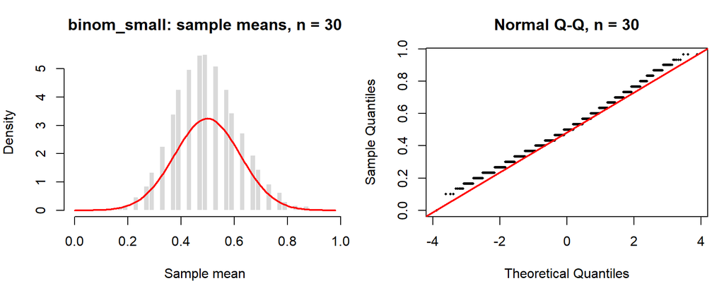

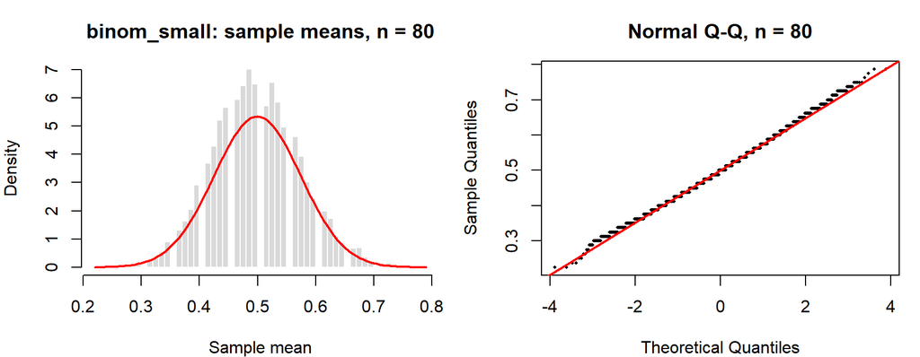

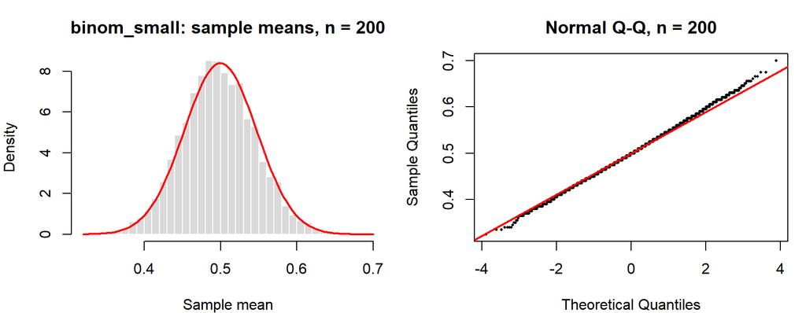

```r
# Show values below, at, and above my chosen n
for (n in c(30, 80, 200)) {
  plot_diagnostics(simulate_means(populations[[pop]], n, B, student_id), n, pop)
}
```

$$\boxed{n = \text{80}}$$

I used the same standard as every other population: |skewness| ≤ 0.25, |excess kurtosis| ≤ 0.3, and Q-Q correlation ≥ 0.998. Kurtosis passed from n = 5 on, and skewness passed from n = 25 on, roughly following the theoretical 1.19/√n. The Q-Q correlation was the last criterion to pass: 0.99799 at n = 70, just below the cutoff, and 0.99803 at n = 80, staying above 0.998 at every larger n. At n = 30 the Q-Q plot still has visible steps and a slight upward bend in the right tail. At n = 80 the steps are small and the points follow the line, and the histogram is bell-shaped. So this population needs about n = 80, the same as the exponential, even though its skewness (1.19) is lower than the exponential’s (2). Its discreteness adds to the sample size needed.

## 7. Limitations and surprises

If I had used only skewness and kurtosis, I would have called this population normal at n = 25: skewness was 0.21 and kurtosis was near 0. But the Q-Q correlation was still only 0.995, and the Q-Q plot showed a clear staircase. The reason is discreteness combined with the pile-up at 0: about 59% of all draws are 0, so the sample mean can only take a small number of values (7 different values at n = 2, 28 at n = 30, 43 at n = 60). It took until n = 80 for the steps to become small enough. This is why I used more than one criterion: the moment-based statistics missed a problem that the Q-Q plot caught. The Shapiro-Wilk test still rejected even at n = 500 (p = 0.027), because it keeps detecting the discreteness.